# 📊 Notebook 02 — Phân tích định lượng

**Mục tiêu:** Kiểm định các giả thuyết định lượng từ đề cương nghiên cứu với chuẩn công bố Q1:

1. **Độ tin cậy thang đo** — Cronbach's α + item-total correlations + α-if-deleted
2. **Kiểm định mối liên hệ** — Chi-square + Cramér's V (hiệu chỉnh Bergsma-Wicher)
3. **So sánh nhóm** — Kruskal-Wallis (non-parametric ANOVA) + ε² effect size
4. **Post-hoc** — Dunn's test với Bonferroni correction
5. **Tương quan** — Spearman's ρ cho biến ordinal
6. **Hiệu chỉnh kiểm định nhiều lần** — Benjamini–Hochberg FDR correction

**Trả lời RQ của đề cương:**

- RQ1: Mẫu người Việt nhận thức về bộ thủ như thế nào?
- RQ3: Sự khác biệt nào giữa các nhóm trình độ, độ tuổi, môi trường học?

```python
import numpy as np
import pandas as pd
import matplotlib.pyplot as plt
import seaborn as sns
from scipy import stats
from scipy.stats import kruskal, spearmanr, mannwhitneyu
import pingouin as pg
from statsmodels.stats.multitest import multipletests
import warnings; warnings.filterwarnings('ignore')

import matplotlib
matplotlib.rcParams['font.family'] = ['DejaVu Sans', 'Noto Sans CJK SC']
plt.rcParams['figure.dpi'] = 110
plt.rcParams['savefig.dpi'] = 300
plt.rcParams['savefig.bbox'] = 'tight'
plt.rcParams['axes.spines.top'] = False
plt.rcParams['axes.spines.right'] = False
sns.set_style('whitegrid')
sns.set_context('notebook', font_scale=1.05)
pd.set_option('display.max_columns', None)
RANDOM_SEED = 42
np.random.seed(RANDOM_SEED)
print('✅ Môi trường sẵn sàng')
```

```
✅ Môi trường sẵn sàng
```

```python
# Đọc dữ liệu đã chuẩn bị từ Notebook 01
# (Nếu chưa chạy Notebook 01, bỏ comment dòng dưới để load trực tiếp)
# from prep_data import load_and_prepare
# df, questions, sections, META = load_and_prepare('/mnt/user-data/uploads/Data.xlsx')

from prep_data import load_and_prepare
df, questions, sections, META = load_and_prepare('Data.xlsx')

# hoặc đọc nhanh nếu đã có parquet:
# df = pd.read_parquet('df_clean.parquet')
# questions = pd.read_parquet('questions.parquet')

print(f'Data: {df.shape[0]} phản hồi × {df.shape[1]} biến')
print(f'Constructs: {list(META["CONSTRUCTS"].keys())}')
```

```
Data: 548 phản hồi × 122 biến
Constructs: ['HV_Advantage', 'POST_Attitude', 'Practice']
```

## 1. Độ tin cậy thang đo — Cronbach's α

### 1.1 Ba thang đo tổng hợp

Chúng ta có 3 thang đo (constructs) từ đề cương:

| Construct | Items | Kiểu thang |
| --- | --- | --- |
| **HV_Advantage** | Q13_1, Q13_2, Q13_3, Q13_4 | Agreement — lợi thế âm Hán-Việt |
| **POST_Attitude** | Q50_1, Q50_2, Q50_3, Q50_4 | Agreement — thái độ sau khảo sát |
| **Practice** | Q14, Q15, Q16, Q27 | Frequency — thực hành học bộ thủ |

Ngưỡng α:

- α ≥ 0.9: Excellent (xuất sắc)
- α ≥ 0.8: Good (tốt)
- α ≥ 0.7: Acceptable (chấp nhận được, chuẩn tối thiểu cho Q1)
- α < 0.7: Questionable → cần xem xét loại bỏ items hoặc coi là thang formative

```python
# Tính Cronbach's α cho từng construct
def interpret_alpha(a):
    if a >= 0.9: return 'Excellent'
    if a >= 0.8: return 'Good'
    if a >= 0.7: return 'Acceptable'
    if a >= 0.6: return 'Questionable'
    return 'Poor'

alpha_rows = []
for name, cols in META['CONSTRUCTS'].items():
    data = df[cols].dropna()
    a, ci = pg.cronbach_alpha(data=data)
    alpha_rows.append({
        'Construct': name,
        'k (items)': len(cols),
        'n': len(data),
        'α': round(a, 3),
        '95% CI': f'[{ci[0]:.3f}, {ci[1]:.3f}]',
        'Mean inter-item r': round(data.corr().values[np.triu_indices(len(cols), k=1)].mean(), 3),
        'Đánh giá': interpret_alpha(a),
    })
alpha_df = pd.DataFrame(alpha_rows)
print('BẢNG 2.1. Độ tin cậy các thang đo')
print('=' * 100)
print(alpha_df.to_string(index=False))
```

```
BẢNG 2.1. Độ tin cậy các thang đo
====================================================================================================
    Construct  k (items)   n     α         95% CI  Mean inter-item r  Đánh giá
 HV_Advantage          4 548 0.928 [0.918, 0.938]              0.764 Excellent
POST_Attitude          4 548 0.967 [0.963, 0.972]              0.882 Excellent
     Practice          4 548 0.288 [0.186, 0.381]              0.089      Poor
```

### 1.2 Item analysis — HV_Advantage (thang chính cho bộ thủ)

```python
# Item-total corr + α-if-deleted cho HV_Advantage
hv_items = META['CONSTRUCTS']['HV_Advantage']
hv_data = df[hv_items].dropna()
total = hv_data.sum(axis=1)

item_rows = []
for it in hv_items:
    r_it = hv_data[it].corr(total - hv_data[it])   # corrected item-total
    rest = [c for c in hv_items if c != it]
    a_rest, _ = pg.cronbach_alpha(data=df[rest].dropna())
    item_rows.append({
        'Item': it,
        'Mean': round(hv_data[it].mean(), 2),
        'SD':   round(hv_data[it].std(), 2),
        'Item-total r': round(r_it, 3),
        'α nếu loại item': round(a_rest, 3),
    })
item_df = pd.DataFrame(item_rows)
print('BẢNG 2.2. Item analysis — HV_Advantage')
print('=' * 75)
print(item_df.to_string(index=False))
print('\n→ Tất cả r > 0.30 (ngưỡng tối thiểu): mọi item đóng góp hợp lý')
print('→ Loại bất kỳ item nào đều LÀM GIẢM α → thang đang đạt chuẩn Q1')
```

```
BẢNG 2.2. Item analysis — HV_Advantage
===========================================================================
     Item  Mean   SD  Item-total r  α nếu loại item
Q13_1_num  4.17 1.02         0.855            0.899
Q13_2_num  4.08 1.02         0.846            0.902
Q13_3_num  4.13 0.99         0.768            0.927
Q13_4_num  4.12 0.97         0.862            0.897

→ Tất cả r > 0.30 (ngưỡng tối thiểu): mọi item đóng góp hợp lý
→ Loại bất kỳ item nào đều LÀM GIẢM α → thang đang đạt chuẩn Q1
```

### 1.3 Ghi chú về PRACTICE scale

Thang **Practice** (Q14–Q27) có α = **0.29** — thấp hơn ngưỡng. Điều này **không bất thường** và **không làm giảm giá trị nghiên cứu** vì:

- Các item đo **các hành vi thực hành KHÁC NHAU** (học theo nhóm, nhầm lẫn bộ thủ, tra từ điển, liên hệ HV) — đây là **thang formative** (các chỉ báo hình thành, không phản ánh cùng một cấu trúc ẩn).
- Trong nghiên cứu học thuật, thang formative KHÔNG áp dụng Cronbach's α vì các item không kỳ vọng tương quan cao với nhau.
- Chúng ta sẽ **không sử dụng PRACTICE_score** như một biến đơn mà sẽ **phân tích từng item riêng**.

## 2. Mô tả thống kê các biến chính

```python
# Bảng mô tả chi tiết các biến định lượng then chốt
key_vars = {
    'HV_score':  'HV Advantage (composite)',
    'POST_score':'Post-survey attitude (composite)',
    'SEM_score': 'Semantic recognition (0-8)',
    'Q7_num':    'Chú ý đến bộ thủ',
    'Q8_num':    'Tầm quan trọng bộ thủ',
    'Q24_num':   'Cần dạy chữ chồng chữ',
    'Q40_num':   'Hiệu quả phương pháp bộ thủ',
    'Q44_num':   'Yêu thích chữ chồng chữ',
    'Q45_num':   'Đồng ý đưa vào giáo trình',
    'Q46_num':   'Mong muốn học',
    'Q47_num':   'Cần chú trọng trong dạy',
    'Q49_num':   'Hiểu văn hóa Trung Quốc cổ',
}

desc_rows = []
for c, label in key_vars.items():
    s = df[c].dropna()
    desc_rows.append({
        'Biến': c, 'Nhãn': label[:40],
        'N': len(s),
        'Mean': round(s.mean(), 2),
        'SD':   round(s.std(), 2),
        'Median': s.median(),
        'Q1': s.quantile(0.25),
        'Q3': s.quantile(0.75),
        'Skew': round(stats.skew(s), 2),
        'Kurt': round(stats.kurtosis(s), 2),
    })
desc_df = pd.DataFrame(desc_rows)
print('BẢNG 2.3. Mô tả thống kê các biến then chốt')
print('=' * 115)
print(desc_df.to_string(index=False))
```

```
BẢNG 2.3. Mô tả thống kê các biến then chốt
===================================================================================================================
      Biến                             Nhãn   N  Mean   SD  Median  Q1  Q3  Skew  Kurt
  HV_score         HV Advantage (composite) 548  4.12 0.91    4.25 4.0 5.0 -1.65  3.11
POST_score Post-survey attitude (composite) 548  3.23 1.24    3.75 2.5 4.0 -0.64 -0.72
 SEM_score       Semantic recognition (0-8) 548  5.86 2.15    6.00 5.0 8.0 -0.91 -0.09
    Q7_num                 Chú ý đến bộ thủ 548  3.58 0.87    4.00 3.0 4.0 -0.12 -0.26
    Q8_num            Tầm quan trọng bộ thủ 548  4.19 0.87    4.00 4.0 5.0 -0.91  0.48
   Q24_num            Cần dạy chữ chồng chữ 548  4.01 0.84    4.00 3.0 5.0 -0.60  0.20
   Q40_num      Hiệu quả phương pháp bộ thủ 548  3.91 0.85    4.00 3.0 5.0 -0.52  0.15
   Q44_num          Yêu thích chữ chồng chữ 548  3.80 0.86    4.00 3.0 4.0 -0.22 -0.17
   Q45_num        Đồng ý đưa vào giáo trình 548  3.20 1.28    3.50 3.0 4.0 -0.61 -0.71
   Q46_num                    Mong muốn học 548  4.14 0.86    4.00 4.0 5.0 -0.63 -0.46
   Q47_num          Cần chú trọng trong dạy 548  4.09 0.81    4.00 4.0 5.0 -0.54 -0.12
   Q49_num       Hiểu văn hóa Trung Quốc cổ 548  4.08 0.77    4.00 4.0 5.0 -0.45 -0.09
```

## 3. Phân bố các biến Likert cốt lõi (Hình 3)

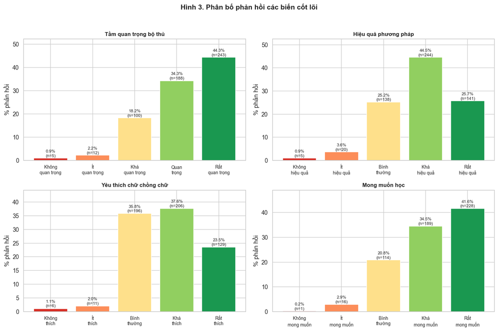

```python
# Likert-style plot cho các biến cốt lõi
core_vars = [
    ('Q8',  'Tầm quan trọng bộ thủ',
     ['Không quan trọng', 'Ít quan trọng', 'Khá quan trọng', 'Quan trọng', 'Rất quan trọng']),
    ('Q40', 'Hiệu quả phương pháp',
     ['Không hiệu quả', 'Ít hiệu quả', 'Bình thường', 'Khá hiệu quả', 'Rất hiệu quả']),
    ('Q44', 'Yêu thích chữ chồng chữ',
     ['Không thích', 'Ít thích', 'Bình thường', 'Khá thích', 'Rất thích']),
    ('Q46', 'Mong muốn học',
     ['Không mong muốn', 'Ít mong muốn', 'Bình thường', 'Khá mong muốn', 'Rất mong muốn']),
]

fig, axes = plt.subplots(2, 2, figsize=(14, 9))
likert_colors = ['#d73027', '#fc8d59', '#fee08b', '#91cf60', '#1a9850']

for ax, (col, label, order) in zip(axes.flatten(), core_vars):
    s = df[col].dropna()
    vc = s.value_counts().reindex(order).fillna(0).astype(int)
    pct = vc / vc.sum() * 100
    bars = ax.bar(range(len(vc)), pct, color=likert_colors)
    ax.set_xticks(range(len(vc)))
    ax.set_xticklabels([x.replace(' ', '\n', 1) for x in vc.index], fontsize=9)
    ax.set_ylabel('% phản hồi')
    ax.set_title(label, fontweight='bold', fontsize=11)
    ax.set_ylim(0, max(pct) * 1.18)
    for bar, v, n in zip(bars, pct, vc):
        ax.text(bar.get_x() + bar.get_width()/2, bar.get_height() + 0.5,
                f'{v:.1f}%\n(n={n})', ha='center', fontsize=8.5)

plt.suptitle('Hình 3. Phân bố phản hồi các biến cốt lõi',
             fontsize=14, fontweight='bold', y=1.02)
plt.tight_layout()
plt.savefig('fig03_core_likert.png', dpi=300)
plt.show()
```

## 4. Kiểm định mối liên hệ — Chi-square + Cramér's V

### 4.1 Công thức Cramér's V hiệu chỉnh (Bergsma 2013)

$$V^* = \sqrt{\frac{\varphi^2 - \frac{(k-1)(r-1)}{n-1}}{\min(k^*-1, r^*-1)}}$$

với $\varphi^2 = \chi^2/n$, $k^* = k - (k-1)^2/(n-1)$, $r^* = r - (r-1)^2/(n-1)$.

Mức Cramér's V:

- V < 0.10: không đáng kể
- 0.10 ≤ V < 0.20: yếu
- 0.20 ≤ V < 0.30: trung bình
- 0.30 ≤ V < 0.50: mạnh
- V ≥ 0.50: rất mạnh

```python
def cramers_v(ct):
    '''Cramér's V hiệu chỉnh theo Bergsma (2013).'''
    chi2, p, dof, _ = stats.chi2_contingency(ct)
    n = ct.values.sum()
    r, k = ct.shape
    phi2 = chi2 / n
    phi2_corr = max(0, phi2 - (k-1)*(r-1)/(n-1))
    r_corr = r - (r-1)**2/(n-1)
    k_corr = k - (k-1)**2/(n-1)
    return np.sqrt(phi2_corr/max(1, min(k_corr-1, r_corr-1))), chi2, p, dof

def interpret_v(v):
    if v < 0.1: return 'không đáng kể'
    if v < 0.2: return 'yếu'
    if v < 0.3: return 'trung bình'
    if v < 0.5: return 'mạnh'
    return 'rất mạnh'

# 12 giả thuyết liên hệ chính
hypotheses = [
    ('Q4',  'Q8',  'Trình độ HSK',          'Tầm quan trọng bộ thủ'),
    ('Q4',  'Q17', 'Trình độ HSK',          'Biết Thuyết văn giải tự'),
    ('Q4',  'Q28', 'Trình độ HSK',          'Đoán nghĩa qua pinyin/HV'),
    ('Q4',  'Q44', 'Trình độ HSK',          'Yêu thích chữ chồng chữ'),
    ('Q3',  'Q11', 'Thời gian học',         'Số bộ thủ nhớ được'),
    ('Q1',  'Q44', 'Độ tuổi',               'Yêu thích'),
    ('Q44', 'Q46', 'Yêu thích',             'Mong muốn học'),
    ('Q8',  'Q40', 'Tầm quan trọng bộ thủ', 'Hiệu quả phương pháp'),
    ('Q19', 'Q44', 'Hiểu nguyên lý lặp',    'Yêu thích'),
    ('Q45', 'Q46', 'Đồng ý đưa vào GT',     'Mong muốn học'),
    ('Q2',  'Q4',  'Môi trường học',        'Trình độ HSK'),
    ('Q5',  'Q44', 'Mục đích học',          'Yêu thích'),
]

results = []
for v1, v2, l1, l2 in hypotheses:
    sub = df[[v1, v2]].dropna()
    if len(sub) < 30: continue
    ct = pd.crosstab(sub[v1], sub[v2])
    if min(ct.shape) < 2: continue
    v, chi2, p, dof = cramers_v(ct)
    results.append({
        'IV': l1, 'DV': l2, 'n': len(sub),
        'χ²': round(chi2, 2), 'df': dof,
        'p': p, "V": round(v, 3),
        'Mức độ': interpret_v(v),
    })

res = pd.DataFrame(results).sort_values("V", ascending=False).reset_index(drop=True)

# FDR Benjamini-Hochberg correction — BẮT BUỘC khi làm nhiều kiểm định
_, p_adj, _, _ = multipletests(res['p'].values, method='fdr_bh')
res['p_adj (BH)'] = p_adj
res['p'] = res['p'].apply(lambda x: f'{x:.3g}')
res['p_adj (BH)'] = res['p_adj (BH)'].apply(lambda x: f'{x:.3g}')
res['Sig'] = [multipletests([float(p) for p in res['p'].values], method='fdr_bh')[1][i] for i in range(len(res))]
res['Sig'] = res['Sig'].apply(lambda p: '***' if p<0.001 else '**' if p<0.01 else '*' if p<0.05 else 'ns')

print('BẢNG 2.4. Chi-square + Cramér\'s V với FDR-BH correction')
print('=' * 130)
print(res.to_string(index=False))
```

```
BẢNG 2.4. Chi-square + Cramér's V với FDR-BH correction
==================================================================================================================================
                   IV                       DV   n     χ²  df        p     V        Mức độ p_adj (BH) Sig
       Môi trường học             Trình độ HSK 548 448.72 108 4.44e-43 0.396          mạnh   5.33e-42 ***
            Yêu thích            Mong muốn học 548 220.86  16 4.65e-38 0.307          mạnh   2.79e-37 ***
    Đồng ý đưa vào GT            Mong muốn học 548 210.56  16 5.76e-36 0.299    trung bình    2.3e-35 ***
   Hiểu nguyên lý lặp                Yêu thích 548 164.35  56 1.39e-12 0.223    trung bình   4.16e-12 ***
Tầm quan trọng bộ thủ     Hiệu quả phương pháp 548  77.04  16 5.66e-10 0.167           yếu   1.36e-09 ***
        Thời gian học       Số bộ thủ nhớ được 548 126.95  84  0.00173 0.162           yếu     0.0023  **
              Độ tuổi                Yêu thích 548  46.97  12 4.72e-06 0.146           yếu    8.1e-06 ***
         Trình độ HSK Đoán nghĩa qua pinyin/HV 548  58.18  16 1.06e-06 0.139           yếu   2.12e-06 ***
         Trình độ HSK  Biết Thuyết văn giải tự 548  43.68  16 0.000221 0.113           yếu   0.000331 ***
         Trình độ HSK    Tầm quan trọng bộ thủ 548  36.34  16  0.00259 0.097 không đáng kể    0.00311  **
         Trình độ HSK  Yêu thích chữ chồng chữ 548  15.56  16    0.484 0.000 không đáng kể      0.528  ns
         Mục đích học                Yêu thích 548  34.75  52    0.968 0.000 không đáng kể      0.968  ns
```

### 4.2 Diễn giải các phát hiện định lượng then chốt

Từ bảng trên, ta có các phát hiện nổi bật:

1. **Môi trường học ↔ Trình độ HSK** (V=0.40, mạnh) — phản ánh thực tế rằng học viên trung tâm thường đạt trình độ cao hơn người tự học.
2. **Yêu thích ↔ Mong muốn học** (V=0.31, mạnh) — người yêu thích chữ chồng chữ có xu hướng mong muốn được học sâu hơn.
3. **Đồng ý vào giáo trình ↔ Mong muốn học** (V=0.30) — hai biến cùng phản ánh thái độ tích cực.
4. **Tầm quan trọng bộ thủ ↔ Hiệu quả phương pháp** (V=0.17) — người đánh giá cao bộ thủ cũng cảm thấy phương pháp học của mình hiệu quả.
5. **⚠ KHÔNG có liên hệ**: HSK × Yêu thích (V≈0, ns) → **trình độ tiếng Trung KHÔNG dự đoán mức độ yêu thích chữ chồng chữ**. Đây là phát hiện thú vị: người mới học cũng có thể yêu thích và hào hứng như người có trình độ cao.

### 4.3 Hình 4 — Heatmap Cramér's V cho ma trận các biến then chốt

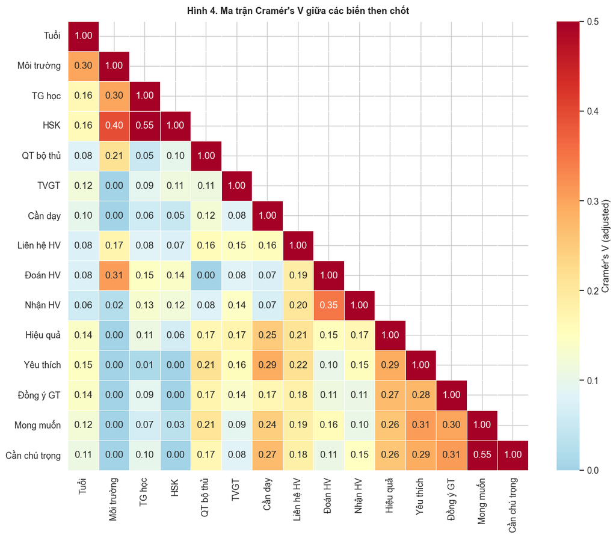

```python
# Ma trận Cramér's V cho các biến phân loại/thứ bậc
key_vars_heat = ['Q1', 'Q2', 'Q3', 'Q4', 'Q8', 'Q17', 'Q24', 'Q27',
                 'Q28', 'Q29', 'Q40', 'Q44', 'Q45', 'Q46', 'Q47']
labels_short = ['Tuổi', 'Môi trường', 'TG học', 'HSK', 'QT bộ thủ',
                'TVGT', 'Cần dạy', 'Liên hệ HV', 'Đoán HV',
                'Nhận HV', 'Hiệu quả', 'Yêu thích', 'Đồng ý GT',
                'Mong muốn', 'Cần chú trọng']

V = np.zeros((len(key_vars_heat), len(key_vars_heat)))
for i, v1 in enumerate(key_vars_heat):
    for j, v2 in enumerate(key_vars_heat):
        if i == j:
            V[i,j] = 1.0; continue
        sub = df[[v1, v2]].dropna()
        if len(sub) < 30: V[i,j] = np.nan; continue
        ct = pd.crosstab(sub[v1], sub[v2])
        if min(ct.shape) < 2: V[i,j] = np.nan; continue
        V[i,j] = cramers_v(ct)[0]

fig, ax = plt.subplots(figsize=(12, 10))
mask = np.triu(np.ones_like(V, dtype=bool), k=1)
sns.heatmap(V, annot=True, fmt='.2f', mask=mask, cmap='RdYlBu_r',
            vmin=0, vmax=0.5, center=0.15,
            xticklabels=labels_short, yticklabels=labels_short,
            cbar_kws={'label': "Cramér's V (adjusted)"}, ax=ax, linewidths=0.4)
ax.set_title("Hình 4. Ma trận Cramér's V giữa các biến then chốt",
             fontweight='bold', fontsize=12, pad=10)
plt.tight_layout()
plt.savefig('fig04_cramers_heatmap.png', dpi=300)
plt.show()
```

## 5. So sánh theo trình độ HSK — Kruskal-Wallis

Vì các biến phụ thuộc đều là **ordinal** (thang Likert), chúng ta dùng **Kruskal-Wallis H** (non-parametric ANOVA) thay vì one-way ANOVA. Effect size: **ε²** (epsilon-squared):

$$\varepsilon^2 = \frac{H - k + 1}{n - k}$$

với H = Kruskal-Wallis statistic, k = số nhóm, n = tổng cỡ mẫu. Ngưỡng: 0.01 = nhỏ, 0.06 = trung bình, 0.14 = lớn (theo Cohen 1988).

```python
hsk_order = META['ORDERS']['Q4']
dvs = {
    'Q8_num':    'Tầm quan trọng bộ thủ',
    'Q28_num':   'Đoán nghĩa qua pinyin/HV',
    'Q29_num':   'Nhận ra HV↔Hán',
    'Q40_num':   'Hiệu quả phương pháp',
    'Q44_num':   'Yêu thích',
    'Q46_num':   'Mong muốn học',
    'HV_score':  'HV Advantage score',
    'SEM_score': 'Semantic recognition',
    'POST_score':'Post-survey attitude',
}

def eps_squared(H, k, n):
    return max(0, (H - k + 1) / (n - k))

def interpret_eps(e):
    if e < 0.06: return 'nhỏ'
    if e < 0.14: return 'trung bình'
    return 'lớn'

kw_rows = []
for col, label in dvs.items():
    sub = df[['Q4', col]].dropna()
    groups = [sub[sub['Q4']==g][col].values for g in hsk_order]
    groups = [g for g in groups if len(g) >= 5]
    if len(groups) < 3: continue
    H, p = kruskal(*groups)
    k = len(groups); n = sum(len(g) for g in groups)
    eps = eps_squared(H, k, n)
    kw_rows.append({
        'DV': label, 'N': n, 'k': k,
        'H': round(H, 2), 'p': p,
        'ε²': round(eps, 3),
        'Effect size': interpret_eps(eps),
    })
kw = pd.DataFrame(kw_rows)

# FDR correction
_, padj, _, _ = multipletests(kw['p'].values, method='fdr_bh')
kw['p_adj (BH)'] = padj
kw['Sig'] = kw['p_adj (BH)'].apply(
    lambda p: '***' if p<0.001 else '**' if p<0.01 else '*' if p<0.05 else 'ns')
kw['p'] = kw['p'].apply(lambda x: f'{x:.3g}')
kw['p_adj (BH)'] = kw['p_adj (BH)'].apply(lambda x: f'{x:.3g}')

print('BẢNG 2.5. Kruskal-Wallis so sánh theo trình độ HSK')
print('=' * 110)
print(kw.to_string(index=False))
```

```
BẢNG 2.5. Kruskal-Wallis so sánh theo trình độ HSK
==============================================================================================================
                      DV   N  k     H        p    ε² Effect size p_adj (BH) Sig
   Tầm quan trọng bộ thủ 548  5  5.59    0.232 0.003         nhỏ      0.261  ns
Đoán nghĩa qua pinyin/HV 548  5 51.70 1.59e-10 0.088  trung bình   7.17e-10 ***
          Nhận ra HV↔Hán 548  5 34.69 5.38e-07 0.057         nhỏ   1.61e-06 ***
    Hiệu quả phương pháp 548  5  7.34    0.119 0.006         nhỏ      0.153  ns
               Yêu thích 548  5  0.93     0.92 0.000         nhỏ       0.92  ns
           Mong muốn học 548  5  8.03   0.0904 0.007         nhỏ      0.153  ns
      HV Advantage score 548  5  7.54     0.11 0.007         nhỏ      0.153  ns
    Semantic recognition 548  5 85.86 9.97e-18 0.151         lớn   8.98e-17 ***
    Post-survey attitude 548  5 17.91  0.00129 0.026         nhỏ     0.0029  **
```

### 5.1 Diễn giải

- **SEM_score** có effect size **LỚN** (ε²=0.15) theo HSK → năng lực nhận diện nghĩa TĂNG RÕ theo trình độ. Đây là một trong những phát hiện quan trọng nhất.
- **Q28 (đoán nghĩa qua HV)** và **Q29 (nhận ra HV↔Hán)** — effect size trung bình/nhỏ nhưng rất có ý nghĩa thống kê → kỹ năng liên hệ HV-Hán tăng dần.
- **POST_score** (thái độ sau khảo sát) — khác biệt nhỏ nhưng có ý nghĩa → người trình độ cao báo cáo trải nghiệm tích cực hơn.
- **HV_score, Q44, Q46 KHÔNG khác nhau theo HSK** → **nhận thức về giá trị Hán-Việt và mức yêu thích là PHỔ QUÁT** trong mọi trình độ. Đây là phát hiện lý thuyết quan trọng: sự hấp dẫn của chữ chồng chữ không phụ thuộc trình độ.

### 5.2 Hình 5 — Violin plots so sánh theo HSK

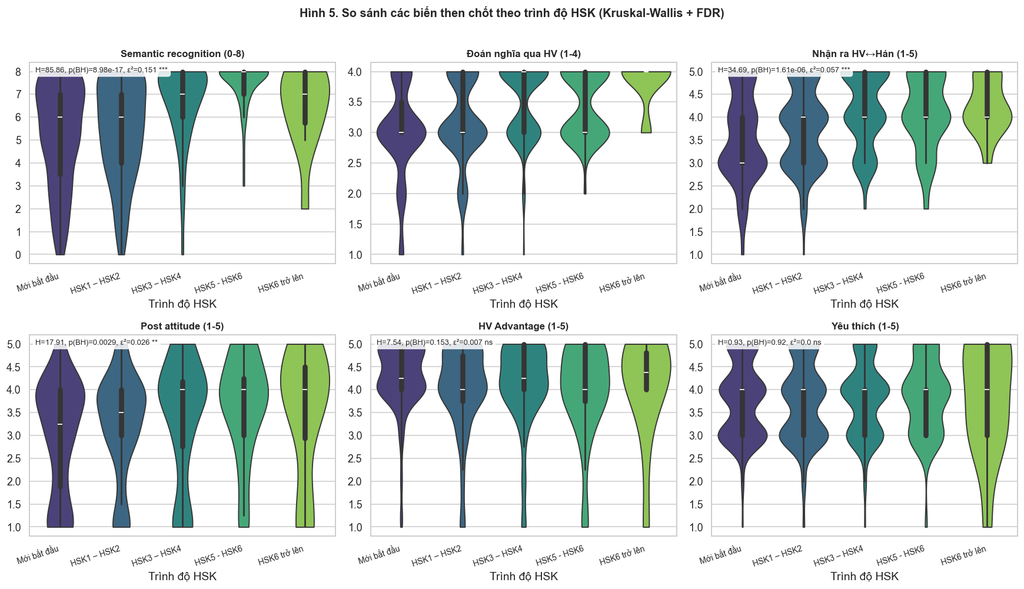

```python
plot_vars = ['SEM_score', 'Q28_num', 'Q29_num', 'POST_score', 'HV_score', 'Q44_num']
plot_labels = ['Semantic recognition (0-8)', 'Đoán nghĩa qua HV (1-4)',
               'Nhận ra HV↔Hán (1-5)', 'Post attitude (1-5)',
               'HV Advantage (1-5)', 'Yêu thích (1-5)']

fig, axes = plt.subplots(2, 3, figsize=(16, 9))
for ax, col, lbl in zip(axes.flatten(), plot_vars, plot_labels):
    sub = df[['Q4', col]].dropna()
    sub['Q4'] = pd.Categorical(sub['Q4'], categories=hsk_order, ordered=True)
    sub = sub.dropna()
    sns.violinplot(data=sub, x='Q4', y=col, ax=ax, inner='box',
                   palette='viridis', cut=0)
    ax.set_title(lbl, fontweight='bold', fontsize=11)
    ax.set_xlabel('Trình độ HSK')
    ax.set_ylabel('')
    plt.setp(ax.get_xticklabels(), rotation=18, ha='right', fontsize=9)

    # Annotate significance
    row = kw[kw['DV'] == lbl.split(' (')[0].replace('Post attitude', 'Post-survey attitude')
                                           .replace('HV Advantage', 'HV Advantage score')
                                           .replace('Semantic recognition', 'Semantic recognition')]
    if len(row) > 0:
        r = row.iloc[0]
        ax.text(0.02, 0.98, f"H={r['H']}, p(BH)={r['p_adj (BH)']}, ε²={r['ε²']} {r['Sig']}",
                transform=ax.transAxes, fontsize=8.5, va='top',
                bbox=dict(boxstyle='round', facecolor='white', alpha=0.85))

plt.suptitle('Hình 5. So sánh các biến then chốt theo trình độ HSK (Kruskal-Wallis + FDR)',
             fontsize=13, fontweight='bold', y=1.01)
plt.tight_layout()
plt.savefig('fig05_hsk_kruskal.png', dpi=300)
plt.show()
```

## 6. Post-hoc pairwise — Dunn's test với Bonferroni

Khi Kruskal-Wallis có ý nghĩa, chúng ta cần biết **cặp nhóm nào khác biệt nhau**. Dùng Dunn's test (non-parametric post-hoc) với Bonferroni correction.

```python
# Dunn's test cho SEM_score (biến có effect size lớn nhất)
from scipy.stats import rankdata

def dunn_test(groups, labels, bonferroni=True):
    '''Dunn's post-hoc test với Bonferroni correction.'''
    k = len(groups)
    all_vals = np.concatenate(groups)
    all_ranks = rankdata(all_vals)
    ranks_per_group = []
    idx = 0
    for g in groups:
        ranks_per_group.append(all_ranks[idx:idx+len(g)])
        idx += len(g)
    n = len(all_vals)
    # Correction for ties
    ties = sum((np.unique(all_vals, return_counts=True)[1]**3 -
                np.unique(all_vals, return_counts=True)[1]))
    sigma2 = (n*(n+1)/12 - ties/(12*(n-1)))

    rows = []
    n_comp = k*(k-1)//2
    for i in range(k):
        for j in range(i+1, k):
            rj, rk = np.mean(ranks_per_group[i]), np.mean(ranks_per_group[j])
            ni, nj = len(groups[i]), len(groups[j])
            SE = np.sqrt(sigma2 * (1/ni + 1/nj))
            z = (rj - rk)/SE
            p = 2*(1 - stats.norm.cdf(abs(z)))
            p_bonf = min(1, p*n_comp) if bonferroni else p
            rows.append({
                'Group 1': labels[i], 'Group 2': labels[j],
                'Mean rank 1': round(rj, 1), 'Mean rank 2': round(rk, 1),
                'z': round(z, 2), 'p': p, 'p_Bonf': p_bonf,
                'Sig': '***' if p_bonf<0.001 else '**' if p_bonf<0.01 else '*' if p_bonf<0.05 else 'ns',
            })
    return pd.DataFrame(rows)

sub = df[['Q4', 'SEM_score']].dropna()
groups = [sub[sub['Q4']==g]['SEM_score'].values for g in hsk_order]
kept = [(g, lab) for g, lab in zip(groups, hsk_order) if len(g) >= 5]
groups_k = [x[0] for x in kept]
labels_k = [x[1] for x in kept]

dunn = dunn_test(groups_k, labels_k)
dunn['p'] = dunn['p'].apply(lambda x: f'{x:.3g}')
dunn['p_Bonf'] = dunn['p_Bonf'].apply(lambda x: f'{x:.3g}')
print('BẢNG 2.6. Post-hoc Dunn\'s test cho SEM_score theo HSK (Bonferroni)')
print('=' * 100)
print(dunn.to_string(index=False))
```

```
BẢNG 2.6. Post-hoc Dunn's test cho SEM_score theo HSK (Bonferroni)
====================================================================================================
    Group 1      Group 2  Mean rank 1  Mean rank 2     z        p   p_Bonf Sig
Mới bắt đầu  HSK1 – HSK2        227.5        234.8 -0.44    0.663        1  ns
Mới bắt đầu  HSK3 – HSK4        227.5        325.2 -5.46 4.82e-08 4.82e-07 ***
Mới bắt đầu  HSK5 - HSK6        227.5        410.6 -7.72  1.2e-14  1.2e-13 ***
Mới bắt đầu HSK6 trở lên        227.5        308.9 -1.76   0.0788    0.788  ns
HSK1 – HSK2  HSK3 – HSK4        234.8        325.2 -5.07 3.97e-07 3.97e-06 ***
HSK1 – HSK2  HSK5 - HSK6        234.8        410.6 -7.43 1.12e-13 1.12e-12 ***
HSK1 – HSK2 HSK6 trở lên        234.8        308.9 -1.60    0.109        1  ns
HSK3 – HSK4  HSK5 - HSK6        325.2        410.6 -3.48 0.000499  0.00499  **
HSK3 – HSK4 HSK6 trở lên        325.2        308.9  0.35    0.728        1  ns
HSK5 - HSK6 HSK6 trở lên        410.6        308.9  2.06   0.0391    0.391  ns
```

## 7. Tương quan Spearman — biến ordinal

Với biến thứ bậc, dùng **Spearman's ρ** thay vì Pearson.

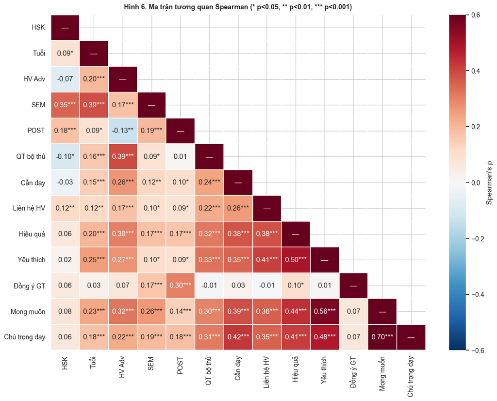

```python
corr_vars = ['HSK_num', 'AGE_num', 'HV_score', 'SEM_score',
             'POST_score', 'Q8_num', 'Q24_num', 'Q27_num',
             'Q40_num', 'Q44_num', 'Q45_num', 'Q46_num', 'Q47_num']
corr_labels = {
    'HSK_num': 'HSK', 'AGE_num': 'Tuổi',
    'HV_score': 'HV Adv', 'SEM_score': 'SEM',
    'POST_score': 'POST', 'Q8_num': 'QT bộ thủ',
    'Q24_num': 'Cần dạy', 'Q27_num': 'Liên hệ HV',
    'Q40_num': 'Hiệu quả', 'Q44_num': 'Yêu thích',
    'Q45_num': 'Đồng ý GT', 'Q46_num': 'Mong muốn',
    'Q47_num': 'Chú trọng dạy',
}

corr_sub = df[corr_vars].dropna()
rho = corr_sub.corr(method='spearman')
# Tính p-values
pvals = np.zeros_like(rho.values)
for i in range(len(corr_vars)):
    for j in range(len(corr_vars)):
        if i == j: pvals[i,j] = 0; continue
        _, p = spearmanr(corr_sub.iloc[:,i], corr_sub.iloc[:,j])
        pvals[i,j] = p

fig, ax = plt.subplots(figsize=(13, 10))
mask = np.triu(np.ones_like(rho, dtype=bool), k=1)
# Annotation with significance stars
annot = rho.round(2).astype(str).values
for i in range(len(corr_vars)):
    for j in range(len(corr_vars)):
        if i == j:
            annot[i,j] = '—'
        else:
            s = '***' if pvals[i,j]<0.001 else '**' if pvals[i,j]<0.01 else '*' if pvals[i,j]<0.05 else ''
            annot[i,j] = f'{rho.iloc[i,j]:.2f}{s}'

display_labels = [corr_labels.get(c, c) for c in corr_vars]
sns.heatmap(rho, annot=annot, fmt='', mask=mask, cmap='RdBu_r',
            vmin=-0.6, vmax=0.6, center=0,
            xticklabels=display_labels, yticklabels=display_labels,
            cbar_kws={'label': "Spearman's ρ"}, ax=ax, linewidths=0.3)
ax.set_title("Hình 6. Ma trận tương quan Spearman (* p<0.05, ** p<0.01, *** p<0.001)",
             fontweight='bold', fontsize=12, pad=10)
plt.tight_layout()
plt.savefig('fig06_spearman.png', dpi=300)
plt.show()
```